# Weather

```r
library(GSODR) #run: install.packages("GSODR")
library(pander)
# to get the GSODR package. You'll need this package to pull in your weather data.
load(system.file("extdata", "isd_history.rda", package = "GSODR"))
```

```r
#Run this in your console to see the Country Names you can pick from:
# View(isd_history)
#Search "United States" in the search bar of the top-right corner of the data Viewer that pops up.
#Or search for any other country you are interested in.
#Goal, select the STNID (station ID) for two different weather stations.
#For example, Rexburg is STNID == "726818-94194"
#Once you have two STNID values selected, go to the next R-chunk.
```

```r
rexburg <- get_GSOD(years = 2023, station = "726818-94194")
#Run: View(rexburg)
#To see what columns mean, go here: https://cran.r-project.org/web/packages/GSODR/vignettes/GSODR.html#appendices

#Then run a similar code to get your station information for your weather stations.
#(If you want to use rexburg, then just use one of the following codes)
finland <- get_GSOD(years = 2023, station = "028750-99999")
# ireland <- get_GSOD(years = 2023, station = "039800-99999")

#Finally, join your two datasets together into one dataset:
# weather2 <- rbind(finland, ireland)
weather <- rbind(finland, rexburg)
# View(weather)

#x=o is alphabetical, its the baseline.

# Model with Null and Alt, should be 3 of them.
# - Ho: B1 = 0 HA B1 != 0
# Ho: B2 = 0 HA B2 != 0
# Ho: B3 = 0 HA B3 != 0
# B1 = Slope of the baseline
# B2 = Change in the Y-intercept
# B3 = Change in the slope
# Explain what the betas are in context
```

## Background

Oulu is a town in Finland and we all know Rexburg. I want to see if there’s a relationship between the minimum temperature and the max temperature for the day and if an increase in the minimum could increase the maximum.

### Hypothesis

$$H_O: \text{There is no interaction between minimum temperature and the
two cities (Oulu or Rexburg) } \beta = 0$$

$$H_A: \text{There is an interaction between minimum temperature and the
two cities (Oulu or Rexburg) } \beta \neq 0$$
$$a = 0.05$$
$$\beta_0 = \text{(Intercept) represents the estimated maximum temperature
(MAX) when the minimum temperature (MIN) is zero for Oulu (since Oulu is
the baseline city)}$$
$$\beta_1 = \text{(Slope for MIN) represents the change in MAX for every
unit change in MIN for Oulu.}$$
$$\beta_2 = \text{(Change in Intercept for Rexburg) represents how much
higher the intercept (i.e., the starting value of MAX when MIN is zero)
is for Rexburg compared to Oulu.}$$

$$\beta_3 = \text{(Change in Slope for Rexburg) represents how much
steeper the slope is for Rexburg compared to Oulu.}$$

### Analysis

```r
weather.lm <- lm(MAX~MIN + NAME + NAME:MIN, data = weather)
pander(summary(weather.lm))
```

|  | Estimate | Std. Error | t value | Pr(>\|t\|) |
| --- | --- | --- | --- | --- |
| **(Intercept)** | 8.382 | 0.2437 | 34.39 | 2.533e-153 |
| **MIN** | 1.005 | 0.02519 | 39.91 | 1.475e-183 |
| **NAMEREXBURG-MADISON COUNTY APT** | 6.462 | 0.346 | 18.68 | 1.251e-63 |
| **MIN:NAMEREXBURG-MADISON COUNTY APT** | 0.1818 | 0.03515 | 5.172 | 3.011e-07 |

Fitting linear model: MAX ~ MIN + NAME + NAME:MIN

| Observations | Residual Std. Error | $R^2$ | Adjusted $R^2$ |
| --- | --- | --- | --- |
| 714 | 4.601 | 0.8625 | 0.8619 |

### Plot with 2 line

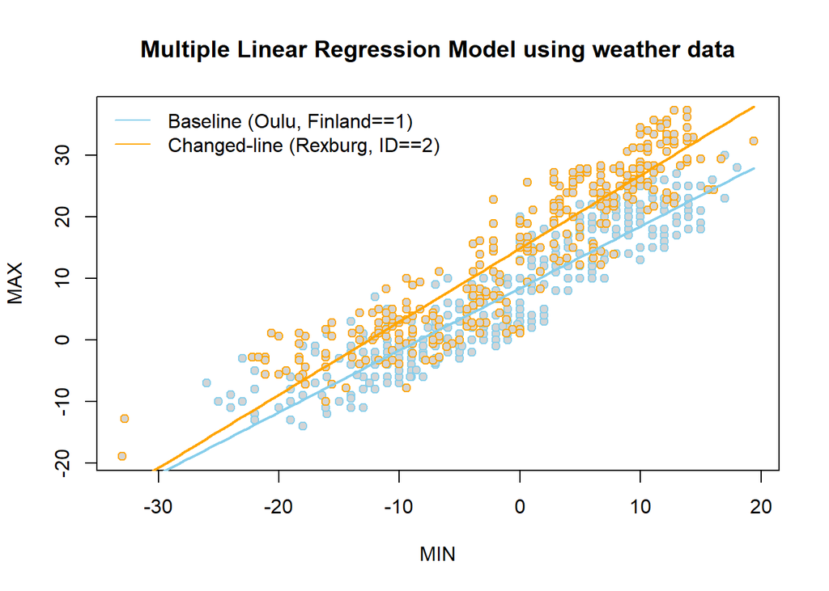

```r
b <- coef(weather.lm)
plot(MAX ~ MIN, data = weather, col = c("skyblue", "orange")[as.factor(weather$NAME)], pch = 21, bg = "gray83", main = "Multiple Linear Regression Model using weather data")

#Baseline for Oulu
curve(b[1] + b[2] * x, col = "skyblue", lwd = 2, add = TRUE)  # Baseline line

#CHanged line for Rexburg
curve((b[1] + b[3]) + (b[2] + b[4]) * x, col = "orange", lwd = 2, add = TRUE)  # Changed line
legend("topleft", legend = c("Baseline (Oulu, Finland==1)", "Changed-line (Rexburg, ID==2)"), bty = "n", lty = 1, col = c("skyblue", "orange"))
```

### Prediction

```r
prediction_oulu <- predict(weather.lm, newdata = data.frame(MIN = 30, NAME = "OULU"))

prediction_rexburg <- predict(weather.lm, newdata = data.frame(MIN = 30, NAME = "REXBURG-MADISON COUNTY APT"))
cat("Predicted MAX for Oulu (MIN = 30):", prediction_oulu, "\n")
```

```
## Predicted MAX for Oulu (MIN = 30): 38.54567
```

```r
cat("Predicted MAX for Rexburg (MIN = 30):", prediction_rexburg, "\n")
```

```
## Predicted MAX for Rexburg (MIN = 30): 50.4614
```

We see from the prediction that when the minimum temperature for both cities is 30, the predicted maximum temperature for Oulu is 38.5 and for Rexburg it’s 50.5. This shows that for the same minimum temperature, the maximum temperature in Rexburg tends to be higher than in Oulu which we do see in the slope.

### Give the slope and the y intercept for both lines

```r
#Baseline Oulu
intercept_oulu <- b[1]
slope_oulu <- b[2]

#Changed-line for Rexburg
intercept_rexburg <- b[1] + b[3]
slope_rexburg <- b[2] + b[4]

cat("Oulu: Intercept =", intercept_oulu, ", Slope =", slope_oulu, "\n")
```

```
## Oulu: Intercept = 8.382358 , Slope = 1.005444
```

```r
cat("Rexburg: Intercept =", intercept_rexburg, ", Slope =", slope_rexburg, "\n")
```

```
## Rexburg: Intercept = 14.84454 , Slope = 1.187229
```

For Oulu we see that as for every 1 degree increase in minimum temperature they have appoximately the same rise in maximum temperature. And even though Rexburg is closely similar it is more of an increase and will equate to more to higher temperatures like in the summer.

### Conclusion

𝛽3 suggests that the relationship between the minimum and maximum differs between Oulu and Rexburg. In particular, Rexburg has a higher intercept and a steeper slope than Oulu, meaning that for the same minimum temperature, the maximum temperature in Rexburg tends to be higher. Both cities show a positive relationship between minimum and maximum, but the rate of change is faster in Rexburg.The model explains approximately 86.19% of the variance in maximum temperature, indicating a good fit. Future studies could include additional variables such as humidity, wind speed, or season to improve the model’s accuracy. We can reject the null hypothesis though further test could be done.